# About Me

Sophie Webster

2/25/2020

## Background

[HUDS](https://dining.harvard.edu/) is Harvard’s dining service and the oldest collegiate foodservice in America. They serve an estimated 25,000 meals daily and 5 million on an annual basis. Each undergraduate house at Harvard has its own servery, kitchen, and dining hall. HUDS has a feedback service for undergraduates, which is available online, by physical cards available in the dining halls, and, mostly popularly, over text. Students can send an SMS to HUDS staff that relays their location and comment. A HUDS house manager responds within 24 hours, fielding the student’s question, praise, or critique.

## The Data

Having used this service many times (and grown very fond of it in the process), I thought it would be fascinating to look at the data attached to each message: the timestamps, the house of origin, and, of course, the content. I visited Crista Martin, HUDS’ Director for Strategic Initiatives & Communications, who graciously offered me a year’s worth of “Text ‘N’ Tell” (as it was once called) data from 2019, parceled in a CSV file. With some cursory tinkering, I made a few informative plots to get a sense of where these messages are often coming from.

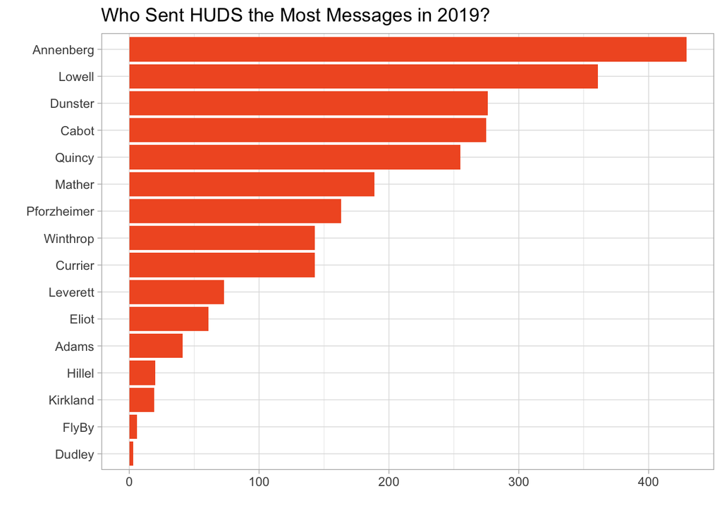

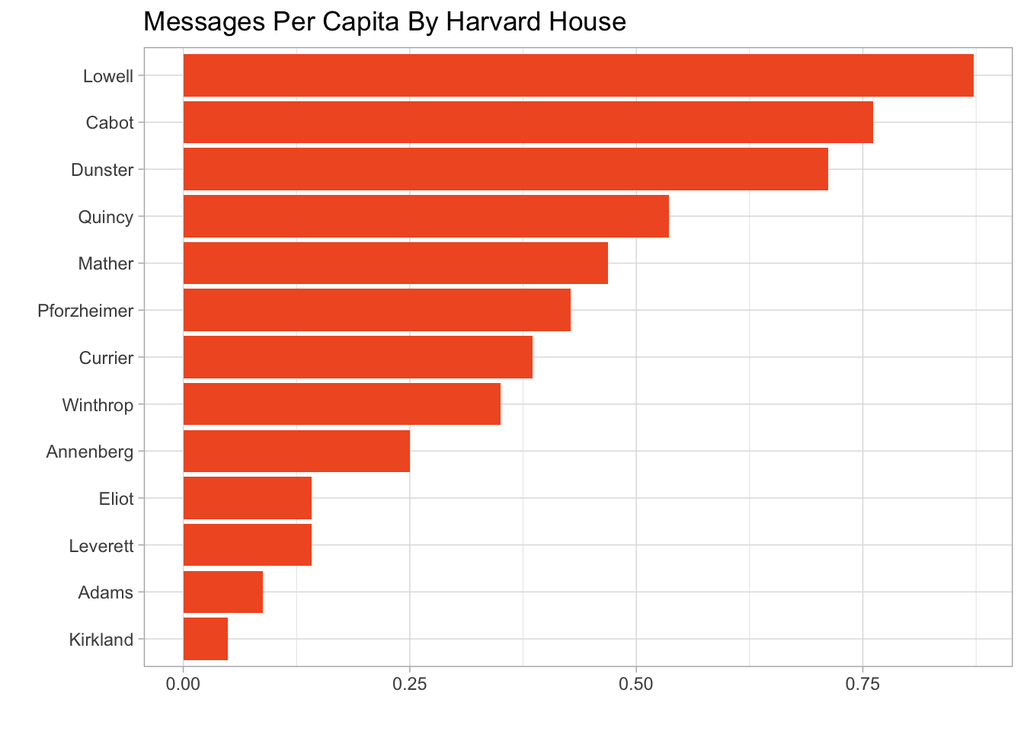

This data sparks many questions I hope to answer, including:

- Are there a few people who consistently send messages? Or a wide variety?
- What are the proportions of positive to negative comments?
- What are the most common words or phrases that the messages contain?
- From where do the students using this service hail?
- What are the most/least liked menu items? Which items generate the most responses?
- Is this a representative sample of opinions? Or do people use this service to express grievances when they are mostly satisfied?

To answer these questions, I will work with the message data and HUDS’ seasonal menus, which I will import and clean as an excel file (I have done so with the Winter 2020 menu already and will add the others as I gain access to them). For daily specifics, I may also scrape the menu from the HUDS website, though I have not yet decided if that will be necessary. Moreover, to answer the last question listed above, I may opt to survey students opinions of the interface and their usage thereof.

This data is available in my [Github repository](https://github.com/sophiecwebster/milestone3).

## About Me

My name is Sophie, and I’m a junior at Harvard College studying Integrative Biology with a secondary in Earth and Planetary Sciences. I love singing with The Radcliffe Pitches, playing the banjo, writing comedy for *Satire V*, and jogging slowly around the Charles River. This is my final project for [Gov 1005](https://www.davidkane.info/files/gov_1005_spring_2020.html), a class on R-driven data science. Feel free to reach out to me by email or on [LinkedIn](https://www.linkedin.com/in/sophie-webster-651b03171/). Thanks for stopping by!